# COVID-19 Vaccines and Economic Recovery in Ecuador 2020-2021.

Daniel Sánchez

April 2022

# Introduction

This is the preliminary study of COVID-19 Vaccines and Economic Recovery in Ecuador. Through empirical models, I aim to determine if there is any sign of a causal effect of vaccination in economic recovery. I will study this phenonemon from 2020 to 2021 in Ecuador. I try to implement a difference-in-differences design using several variables I created as treatments.

# Data wrangling

Load all preliminary stuff:

```r
# Load libraries
library(tidyverse)
library(sandwich)
library(lmtest)
library(modelsummary)
library(fwildclusterboot)
library(fixest)
library(plm)
library(estimatr)
library(psych)
library(openxlsx)
```

```r
library(corrplot)
library(stats)
# Load the data
df<-read.csv('../data/clean_data.csv')
```

I need to wrangle the data before I can start running models.

```r
# Create province factors (for the clustered std. errors)

df$prov<-as.factor(df$province)

# Create post dummy variable

df$post<-ifelse(df$post == 'post',1,0)

# Create the antivax factor variable

df$antivax<-as.factor(df$antivax)

# Convert the month factor to a factor

df$month<-as.factor(df$month)

# Create a year factor

df$year<-as.factor(df$year)

# Conservate a year numeric variable

df$year_n<-as.numeric(df$year)

# Change the reference level to PICHINCHA

df$prov<-relevel(df$prov, 'PICHINCHA')
```

I will also create a panel data frame with the `plm` package

```r
panel_df<-pdata.frame(df, index = 24)
pdim(panel_df)
```

```
## Balanced Panel: n = 24, T = 24, N = 576
```

# Exploratory analysis

## Graphs

### Correlograms

I want to plot a simple correlation matrix for my variables, see what’s what.

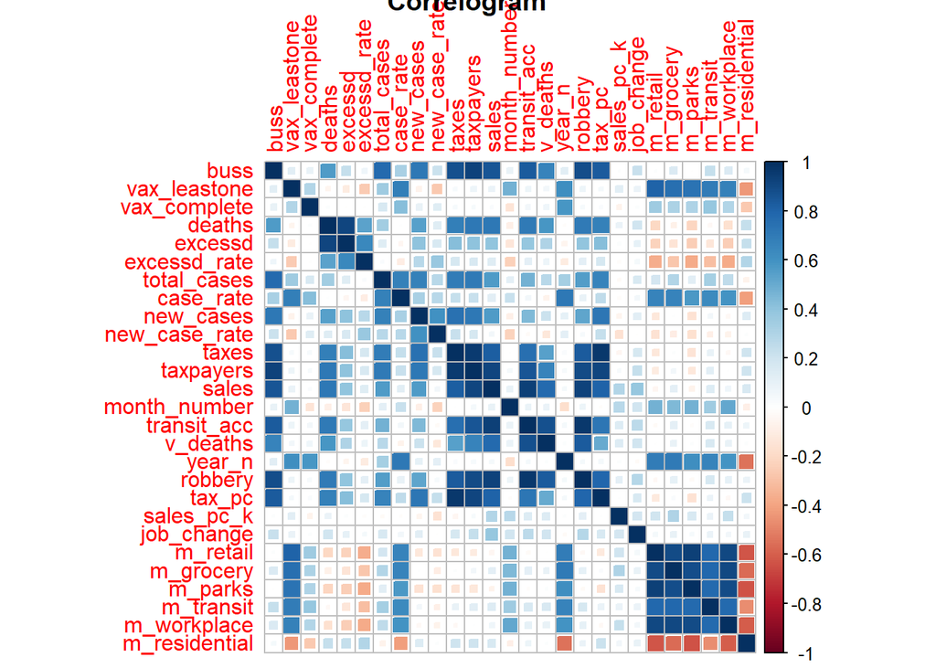

```r
# First create a subset of the data so that the correlation matrix makes sense

df_cor<- df %>%
         select(buss, vax_leastone, vax_complete, deaths, excessd, excessd_rate, total_cases, case_rate, new_cases,
                new_case_rate, taxes, taxpayers, sales, month_number, transit_acc, v_deaths, year_n,
                robbery, tax_pc, sales_pc_k, job_change, m_retail, m_grocery, m_parks, m_transit, m_workplace,
                m_residential)

cor_table<-cor(df_cor,
               use = 'complete.obs')

corrplot(cor_table,
         method = 'square',
         title = 'Correlogram')
```

Now I’d like to separate the data by year, then draw the same corrplots to see if there is any difference.

For 2020:

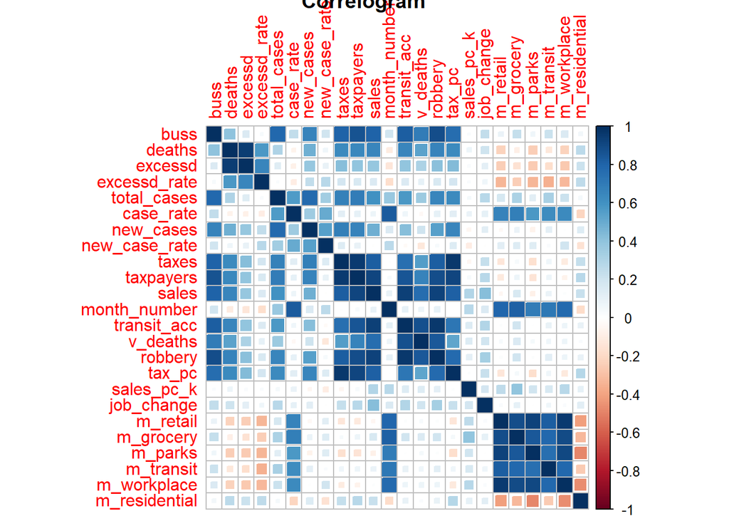

```r
df_20<-subset(df, df$year == 2020)

df_20_cor <- df_20 %>%
             select(buss, deaths, excessd, excessd_rate, total_cases, case_rate, new_cases,
                new_case_rate, taxes, taxpayers, sales, month_number, transit_acc, v_deaths,
                robbery, tax_pc, sales_pc_k, job_change, m_retail, m_grocery, m_parks, m_transit, m_workplace,
                m_residential)

cor_table_20<-cor(df_20_cor,
               use = 'complete.obs')

corrplot(cor_table_20,
         method = 'square',
         title = 'Correlogram')
```

For 2021:

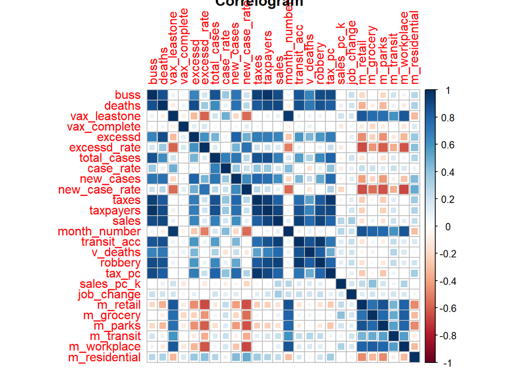

```r
df_21<-subset(df, df$year == 2021)

df_21_cor <- df_21 %>%
             select(buss, deaths, vax_leastone, vax_complete, excessd, excessd_rate, total_cases, case_rate, new_cases,
                new_case_rate, taxes, taxpayers, sales, month_number, transit_acc, v_deaths,
                robbery, tax_pc, sales_pc_k, job_change, m_retail, m_grocery, m_parks, m_transit, m_workplace,
                m_residential)

cor_table_21<-cor(df_21_cor,
               use = 'complete.obs')

corrplot(cor_table_21,
         method = 'square',
         title = 'Correlogram')
```

# Fixed FX Models with vaccination rate treatment

For this section, I try to establish a differences in differences design using the vaccination rate as my treatment variable.

Run a model which includes the most basic variables. Also run the bootstrapping.

```r
# Model
easy<-feols(buss ~ post*vax_leastone + deaths + year + v_deaths + vax_complete | prov + month,
            cluster = ~ prov,
            data = df)

# Bootstrapping test
easy_boot<-boottest(lm(buss ~ post*vax_leastone + deaths + year + v_deaths + vax_complete + month + prov, data = df),
                    clustid = 'prov',
                    param = 'post:vax_leastone',
                    B = 9999)
summary(easy_boot)
```

```
## boottest.lm(object = lm(buss ~ post * vax_leastone + deaths +
##     year + v_deaths + vax_complete + month + prov, data = df),
##     clustid = "prov", param = "post:vax_leastone", B = 9999)
##
##  Hypothesis: 1*post:vax_leastone = 0
##  Observations: 576
##  Bootstr. Iter: 9999
##  Bootstr. Type: rademacher
##  Clustering: 1-way
##  Confidence Sets: 95%
##  Number of Clusters: 24
##
```

| term | estimate | statistic | p.value | conf.low | conf.high |
| --- | --- | --- | --- | --- | --- |
| 1*post:vax_leastone = 0 | 0.812 | 1.459 | 0.021 | 0.058 | 2.289 |

Add the google workplace mobility trend

```r
easy_g<-feols(buss ~ post*vax_leastone + deaths + year + v_deaths + vax_complete + m_workplace| prov + month,
            cluster = ~ prov,
            data = df)
```

```
## NOTE: 48 observations removed because of NA values (RHS: 48).
```

```r
summary(easy_g)
```

```
## OLS estimation, Dep. Var.: buss
## Observations: 528
## Fixed-effects: prov: 24,  month: 12
## Standard-errors: Clustered (prov)
##                     Estimate Std. Error  t value   Pr(>|t|)
## post              -59.222826  37.583688 -1.57576 1.2874e-01
## vax_leastone       -0.397713   0.145396 -2.73539 1.1791e-02 *
## deaths             -0.032692   0.007833 -4.17388 3.6503e-04 ***
## year2021           11.244422   6.870433  1.63664 1.1532e-01
## v_deaths            0.665070   0.082858  8.02662 4.0514e-08 ***
## vax_complete        0.103996   0.091052  1.14217 2.6514e-01
## m_workplace         1.062721   0.743885  1.42861 1.6656e-01
## post:vax_leastone   0.824555   0.507050  1.62618 1.1754e-01
## ---
## Signif. codes:  0 '***' 0.001 '**' 0.01 '*' 0.05 '.' 0.1 ' ' 1
## RMSE: 33.2     Adj. R2: 0.909515
##              Within R2: 0.325871
```

```r
# Bootstrapping test
easyg_boot<-boottest(lm(buss ~ post*vax_leastone + deaths + year + v_deaths + vax_complete + month + prov +
                       m_workplace, data = df),
                    clustid = 'prov',
                    param = 'post:vax_leastone',
                    B = 9999)
summary(easyg_boot)
```

```
## boottest.lm(object = lm(buss ~ post * vax_leastone + deaths +
##     year + v_deaths + vax_complete + month + prov + m_workplace,
##     data = df), clustid = "prov", param = "post:vax_leastone",
##     B = 9999)
##
##  Hypothesis: 1*post:vax_leastone = 0
##  Observations: 528
##  Bootstr. Iter: 9999
##  Bootstr. Type: rademacher
##  Clustering: 1-way
##  Confidence Sets: 95%
##  Number of Clusters: 24
##
```

| term | estimate | statistic | p.value | conf.low | conf.high |
| --- | --- | --- | --- | --- | --- |
| 1*post:vax_leastone = 0 | 0.825 | 1.585 | 0.003 | 0.145 | 2.208 |

Now consider a model with some more variables.

```r
complex_g<-feols(buss ~ post*vax_leastone + deaths + year + v_deaths + vax_complete + m_workplace + robbery +
                 transit_acc + job_change + tax_pc + sales_pc_k| prov + month,
                 cluster = ~ prov,
                 data = df)
```

```
## NOTE: 48 observations removed because of NA values (RHS: 48).
```

```r
summary(complex_g)
```

```
## OLS estimation, Dep. Var.: buss
## Observations: 528
## Fixed-effects: prov: 24,  month: 12
## Standard-errors: Clustered (prov)
##                     Estimate Std. Error   t value   Pr(>|t|)
## post              -49.351079  25.900838 -1.905385 0.06930653 .
## vax_leastone       -0.438601   0.158900 -2.760228 0.01114071 *
## deaths             -0.028866   0.006524 -4.424869 0.00019524 ***
## year2021           15.954292   7.890628  2.021929 0.05496624 .
## v_deaths            0.419577   0.102646  4.087628 0.00045245 ***
## vax_complete        0.161515   0.108851  1.483819 0.15143262
## m_workplace         0.857805   0.668856  1.282496 0.21244431
## robbery             0.130904   0.057410  2.280153 0.03219164 *
## transit_acc         0.028918   0.314615  0.091915 0.92756136
## job_change         -0.000963   0.001915 -0.502653 0.61998726
## tax_pc             -0.032938   0.033958 -0.969957 0.34215817
## sales_pc_k          0.006537   0.013408  0.487533 0.63049565
## post:vax_leastone   0.699511   0.349951  1.998881 0.05757368 .
## ---
## Signif. codes:  0 '***' 0.001 '**' 0.01 '*' 0.05 '.' 0.1 ' ' 1
## RMSE: 31.1     Adj. R2: 0.919734
##              Within R2: 0.408172
```

```r
complexg_boot<-boottest(lm(buss ~ post*vax_leastone + deaths + year + v_deaths + vax_complete + m_workplace + robbery +
                           transit_acc + job_change + tax_pc + sales_pc_k + prov + month,
                           data = df),
                        clustid = 'prov',
                        param = 'post:vax_leastone',
                        B = 9999)
summary(complexg_boot)
```

```
## boottest.lm(object = lm(buss ~ post * vax_leastone + deaths +
##     year + v_deaths + vax_complete + m_workplace + robbery +
##     transit_acc + job_change + tax_pc + sales_pc_k + prov + month,
##     data = df), clustid = "prov", param = "post:vax_leastone",
##     B = 9999)
##
##  Hypothesis: 1*post:vax_leastone = 0
##  Observations: 528
##  Bootstr. Iter: 9999
##  Bootstr. Type: rademacher
##  Clustering: 1-way
##  Confidence Sets: 95%
##  Number of Clusters: 24
##
```

| term | estimate | statistic | p.value | conf.low | conf.high |
| --- | --- | --- | --- | --- | --- |
| 1*post:vax_leastone = 0 | 0.7 | 1.9 | 0.002 | 0.174 | 1.605 |

Add the contagion data to see what happens

```r
complex_g_cases<-feols(buss ~ post*vax_leastone + deaths + year + v_deaths + vax_complete + m_workplace + robbery +
                       transit_acc + job_change + tax_pc + sales_pc_k + total_cases| prov + month,
                 cluster = ~ prov,
                 data = df)
```

```
## NOTE: 48 observations removed because of NA values (RHS: 48).
```

```r
summary(complex_g_cases)
```

```
## OLS estimation, Dep. Var.: buss
## Observations: 528
## Fixed-effects: prov: 24,  month: 12
## Standard-errors: Clustered (prov)
##                    Estimate Std. Error   t value   Pr(>|t|)
## post              -6.966022  15.892820 -0.438313 6.6525e-01
## vax_leastone      -0.577637   0.265781 -2.173358 4.0301e-02 *
## deaths            -0.026079   0.007101 -3.672780 1.2631e-03 **
## year2021          12.307630   7.616962  1.615819 1.1977e-01
## v_deaths           0.424558   0.114854  3.696517 1.1915e-03 **
## vax_complete       0.161602   0.102385  1.578368 1.2814e-01
## m_workplace        0.240887   0.234353  1.027881 3.1469e-01
## robbery            0.087062   0.055943  1.556272 1.3330e-01
## transit_acc        0.024398   0.320965  0.076015 9.4006e-01
## job_change        -0.002813   0.000688 -4.089478 4.5037e-04 ***
## tax_pc            -0.029253   0.029019 -1.008059 3.2391e-01
## sales_pc_k         0.006453   0.011697  0.551718 5.8646e-01
## total_cases        0.001394   0.000073 19.087074 1.3356e-15 ***
## post:vax_leastone  0.187568   0.192643  0.973658 3.4036e-01
## ---
## Signif. codes:  0 '***' 0.001 '**' 0.01 '*' 0.05 '.' 0.1 ' ' 1
## RMSE: 24.7     Adj. R2: 0.949489
##              Within R2: 0.628343
```

```r
complexgcase_boot<-boottest(lm(buss ~ post*vax_leastone + deaths + year + v_deaths + vax_complete + m_workplace +
                               + robbery + transit_acc + job_change + tax_pc + sales_pc_k + prov + month,
                               data = df),
                               clustid = 'prov',
                            param = 'post:vax_leastone',
                            B = 9999)
summary(complexg_boot)
```

```
## boottest.lm(object = lm(buss ~ post * vax_leastone + deaths +
##     year + v_deaths + vax_complete + m_workplace + robbery +
##     transit_acc + job_change + tax_pc + sales_pc_k + prov + month,
##     data = df), clustid = "prov", param = "post:vax_leastone",
##     B = 9999)
##
##  Hypothesis: 1*post:vax_leastone = 0
##  Observations: 528
##  Bootstr. Iter: 9999
##  Bootstr. Type: rademacher
##  Clustering: 1-way
##  Confidence Sets: 95%
##  Number of Clusters: 24
##
```

| term | estimate | statistic | p.value | conf.low | conf.high |
| --- | --- | --- | --- | --- | --- |
| 1*post:vax_leastone = 0 | 0.7 | 1.9 | 0.002 | 0.174 | 1.605 |

Replaces the total cases with new cases

```r
complex_newc<-feols(buss ~ post*vax_leastone + deaths + year + v_deaths + vax_complete + m_workplace + robbery +
                       transit_acc + job_change + tax_pc + sales_pc_k + new_cases| prov + month,
                 cluster = ~ prov,
                 data = df)
```

```
## NOTE: 48 observations removed because of NA values (RHS: 48).
```

```r
summary(complex_newc)
```

```
## OLS estimation, Dep. Var.: buss
## Observations: 528
## Fixed-effects: prov: 24,  month: 12
## Standard-errors: Clustered (prov)
##                     Estimate Std. Error    t value   Pr(>|t|)
## post              -39.491855  28.199999  -1.400420 1.7473e-01
## vax_leastone       -0.099877   0.085545  -1.167537 2.5496e-01
## deaths             -0.039417   0.003011 -13.090009 3.8247e-12 ***
## year2021            3.846905   6.874196   0.559615 5.8115e-01
## v_deaths            0.654225   0.077467   8.445198 1.6729e-08 ***
## vax_complete        0.083940   0.075562   1.110882 2.7810e-01
## m_workplace         0.557996   0.504120   1.106870 2.7979e-01
## robbery             0.091007   0.064712   1.406346 1.7299e-01
## transit_acc         0.167553   0.379207   0.441850 6.6272e-01
## job_change         -0.000741   0.002443  -0.303449 7.6428e-01
## tax_pc             -0.034958   0.034049  -1.026708 3.1524e-01
## sales_pc_k          0.002569   0.010797   0.237923 8.1405e-01
## new_cases           0.013984   0.001111  12.586399 8.4794e-12 ***
## post:vax_leastone   0.604973   0.450898   1.341708 1.9279e-01
## ---
## Signif. codes:  0 '***' 0.001 '**' 0.01 '*' 0.05 '.' 0.1 ' ' 1
## RMSE: 26.6     Adj. R2: 0.941294
##              Within R2: 0.568042
```

```r
complex_newc_boot<-boottest(lm(buss ~ post*vax_leastone + deaths + year + v_deaths + vax_complete + m_workplace +
                               + robbery + transit_acc + job_change + tax_pc + sales_pc_k + new_cases + prov + month,
                               data = df),
                            clustid = 'prov',
                            param = 'post:vax_leastone',
                            B = 9999)
summary(complex_newc_boot)
```

```
## boottest.lm(object = lm(buss ~ post * vax_leastone + deaths +
##     year + v_deaths + vax_complete + m_workplace + +robbery +
##     transit_acc + job_change + tax_pc + sales_pc_k + new_cases +
##     prov + month, data = df), clustid = "prov", param = "post:vax_leastone",
##     B = 9999)
##
##  Hypothesis: 1*post:vax_leastone = 0
##  Observations: 528
##  Bootstr. Iter: 9999
##  Bootstr. Type: rademacher
##  Clustering: 1-way
##  Confidence Sets: 95%
##  Number of Clusters: 24
##
```

| term | estimate | statistic | p.value | conf.low | conf.high |
| --- | --- | --- | --- | --- | --- |
| 1*post:vax_leastone = 0 | 0.605 | 1.326 | 0.052 | -0.003 | 1.728 |

Replace with total case rates

```r
complex_c1<-feols(buss ~ post*vax_leastone + deaths + year + v_deaths + vax_complete + m_workplace + robbery +
                       transit_acc + job_change + tax_pc + sales_pc_k + case_rate| prov + month,
                 cluster = ~ prov,
                 data = df)
```

```
## NOTE: 48 observations removed because of NA values (RHS: 48).
```

```r
summary(complex_c1)
```

```
## OLS estimation, Dep. Var.: buss
## Observations: 528
## Fixed-effects: prov: 24,  month: 12
## Standard-errors: Clustered (prov)
##                     Estimate Std. Error   t value   Pr(>|t|)
## post               -9.293379  29.642811 -0.313512 7.5672e-01
## vax_leastone       -0.569742   0.266495 -2.137905 4.3377e-02 *
## deaths             -0.030176   0.005250 -5.747477 7.4545e-06 ***
## year2021          -16.465918  35.700225 -0.461227 6.4897e-01
## v_deaths            0.453461   0.132783  3.415045 2.3705e-03 **
## vax_complete        0.140101   0.117343  1.193942 2.4467e-01
## m_workplace         0.951692   0.658680  1.444847 1.6199e-01
## robbery             0.123458   0.049629  2.487628 2.0547e-02 *
## transit_acc         0.030302   0.315506  0.096042 9.2432e-01
## job_change         -0.000858   0.001463 -0.586671 5.6314e-01
## tax_pc             -0.032224   0.032465 -0.992572 3.3125e-01
## sales_pc_k          0.001046   0.009783  0.106894 9.1580e-01
## case_rate          15.559659  15.535095  1.001581 3.2697e-01
## post:vax_leastone   0.313038   0.273591  1.144183 2.6432e-01
## ---
## Signif. codes:  0 '***' 0.001 '**' 0.01 '*' 0.05 '.' 0.1 ' ' 1
## RMSE: 30.3     Adj. R2: 0.923656
##              Within R2: 0.438263
```

```r
complex_c1_boot<-boottest(lm(buss ~ post*vax_leastone + deaths + year + v_deaths + vax_complete + m_workplace +
                               + robbery + transit_acc + job_change + tax_pc + sales_pc_k + case_rate + prov + month,
                               data = df),
                            clustid = 'prov',
                            param = 'post:vax_leastone',
                            B = 9999)
summary(complex_c1_boot)
```

```
## boottest.lm(object = lm(buss ~ post * vax_leastone + deaths +
##     year + v_deaths + vax_complete + m_workplace + +robbery +
##     transit_acc + job_change + tax_pc + sales_pc_k + case_rate +
##     prov + month, data = df), clustid = "prov", param = "post:vax_leastone",
##     B = 9999)
##
##  Hypothesis: 1*post:vax_leastone = 0
##  Observations: 528
##  Bootstr. Iter: 9999
##  Bootstr. Type: rademacher
##  Clustering: 1-way
##  Confidence Sets: 95%
##  Number of Clusters: 24
##
```

| term | estimate | statistic | p.value | conf.low | conf.high |
| --- | --- | --- | --- | --- | --- |
| 1*post:vax_leastone = 0 | 0.313 | 1.134 | 0.245 | -0.276 | 0.823 |

Replace with new case rates.

```r
complex_c1_new<-feols(buss ~ post*vax_leastone + deaths + year + v_deaths + vax_complete + m_workplace + robbery +
                       transit_acc + job_change + tax_pc + sales_pc_k + new_case_rate| prov + month,
                 cluster = ~ prov,
                 data = df)
```

```
## NOTE: 48 observations removed because of NA values (RHS: 48).
```

```r
summary(complex_c1_new)
```

```
## OLS estimation, Dep. Var.: buss
## Observations: 528
## Fixed-effects: prov: 24,  month: 12
## Standard-errors: Clustered (prov)
##                     Estimate Std. Error   t value   Pr(>|t|)
## post              -44.142282  21.766730 -2.027970 0.05430043 .
## vax_leastone       -0.225483   0.152385 -1.479689 0.15252409
## deaths             -0.030135   0.005486 -5.492946 0.00001385 ***
## year2021            8.077152  11.020444  0.732924 0.47100898
## v_deaths            0.411773   0.103089  3.994334 0.00057051 ***
## vax_complete        0.150223   0.102724  1.462391 0.15716512
## m_workplace         0.829482   0.638723  1.298657 0.20693205
## robbery             0.126770   0.055849  2.269850 0.03290356 *
## transit_acc         0.041600   0.312223  0.133240 0.89516283
## job_change         -0.000979   0.001961 -0.499522 0.62215677
## tax_pc             -0.031787   0.032889 -0.966488 0.34385330
## sales_pc_k          0.001234   0.009261  0.133212 0.89518467
## new_case_rate      44.453050  34.622905  1.283920 0.21195385
## post:vax_leastone   0.585183   0.275988  2.120319 0.04497957 *
## ---
## Signif. codes:  0 '***' 0.001 '**' 0.01 '*' 0.05 '.' 0.1 ' ' 1
## RMSE: 30.8     Adj. R2: 0.921284
##              Within R2: 0.420804
```

```r
complex_c1new_boot<-boottest(lm(buss ~ post*vax_leastone + deaths + year + v_deaths + vax_complete + m_workplace +
                               + robbery + transit_acc + job_change + tax_pc + sales_pc_k + new_case_rate + prov + month,
                               data = df),
                            clustid = 'prov',
                            param = 'post:vax_leastone',
                            B = 9999)
summary(complex_c1new_boot)
```

```
## boottest.lm(object = lm(buss ~ post * vax_leastone + deaths +
##     year + v_deaths + vax_complete + m_workplace + +robbery +
##     transit_acc + job_change + tax_pc + sales_pc_k + new_case_rate +
##     prov + month, data = df), clustid = "prov", param = "post:vax_leastone",
##     B = 9999)
##
##  Hypothesis: 1*post:vax_leastone = 0
##  Observations: 528
##  Bootstr. Iter: 9999
##  Bootstr. Type: rademacher
##  Clustering: 1-way
##  Confidence Sets: 95%
##  Number of Clusters: 24
##
```

| term | estimate | statistic | p.value | conf.low | conf.high |
| --- | --- | --- | --- | --- | --- |
| 1*post:vax_leastone = 0 | 0.585 | 1.915 | 0.017 | 0.089 | 1.238 |

Show a table with all of the models that were estimated:

```r
modelsummary(list(easy, easy_g, complex_g, complex_g_cases, complex_newc, complex_c1,complex_c1_new),
             stars = c('*' = .1, '**'=0.05, '***' = .01))
```

|  | Model 1 | Model 2 | Model 3 | Model 4 | Model 5 | Model 6 | Model 7 |
| --- | --- | --- | --- | --- | --- | --- | --- |
| post | -62.169 | -59.223 | -49.351* | -6.966 | -39.492 | -9.293 | -44.142* |
|  | (43.025) | (37.584) | (25.901) | (15.893) | (28.200) | (29.643) | (21.767) |
| vax_leastone | -0.313** | -0.398** | -0.439** | -0.578** | -0.100 | -0.570** | -0.225 |
|  | (0.123) | (0.145) | (0.159) | (0.266) | (0.086) | (0.266) | (0.152) |
| deaths | -0.032*** | -0.033*** | -0.029*** | -0.026*** | -0.039*** | -0.030*** | -0.030*** |
|  | (0.007) | (0.008) | (0.007) | (0.007) | (0.003) | (0.005) | (0.005) |
| year2021 | 27.858** | 11.244 | 15.954* | 12.308 | 3.847 | -16.466 | 8.077 |
|  | (12.233) | (6.870) | (7.891) | (7.617) | (6.874) | (35.700) | (11.020) |
| v_deaths | 0.807*** | 0.665*** | 0.420*** | 0.425*** | 0.654*** | 0.453*** | 0.412*** |
|  | (0.047) | (0.083) | (0.103) | (0.115) | (0.077) | (0.133) | (0.103) |
| vax_complete | 0.111 | 0.104 | 0.162 | 0.162 | 0.084 | 0.140 | 0.150 |
|  | (0.102) | (0.091) | (0.109) | (0.102) | (0.076) | (0.117) | (0.103) |
| post × vax_leastone | 0.812 | 0.825 | 0.700* | 0.188 | 0.605 | 0.313 | 0.585** |
|  | (0.554) | (0.507) | (0.350) | (0.193) | (0.451) | (0.274) | (0.276) |
| m_workplace |  | 1.063 | 0.858 | 0.241 | 0.558 | 0.952 | 0.829 |
|  |  | (0.744) | (0.669) | (0.234) | (0.504) | (0.659) | (0.639) |
| robbery |  |  | 0.131** | 0.087 | 0.091 | 0.123** | 0.127** |
|  |  |  | (0.057) | (0.056) | (0.065) | (0.050) | (0.056) |
| transit_acc |  |  | 0.029 | 0.024 | 0.168 | 0.030 | 0.042 |
|  |  |  | (0.315) | (0.321) | (0.379) | (0.316) | (0.312) |
| job_change |  |  | -0.001 | -0.003*** | -0.001 | -0.001 | -0.001 |
|  |  |  | (0.002) | (0.001) | (0.002) | (0.001) | (0.002) |
| tax_pc |  |  | -0.033 | -0.029 | -0.035 | -0.032 | -0.032 |
|  |  |  | (0.034) | (0.029) | (0.034) | (0.032) | (0.033) |
| sales_pc_k |  |  | 0.007 | 0.006 | 0.003 | 0.001 | 0.001 |
|  |  |  | (0.013) | (0.012) | (0.011) | (0.010) | (0.009) |
| total_cases |  |  |  | 0.001*** |  |  |  |
|  |  |  |  | (0.000) |  |  |  |
| new_cases |  |  |  |  | 0.014*** |  |  |
|  |  |  |  |  | (0.001) |  |  |
| case_rate |  |  |  |  |  | 15.560 |  |
|  |  |  |  |  |  | (15.535) |  |
| new_case_rate |  |  |  |  |  |  | 44.453 |
|  |  |  |  |  |  |  | (34.623) |
| Num.Obs. | 576 | 528 | 528 | 528 | 528 | 528 | 528 |
| R2 | 0.906 | 0.917 | 0.927 | 0.954 | 0.947 | 0.931 | 0.928 |
| R2 Adj. | 0.899 | 0.910 | 0.920 | 0.949 | 0.941 | 0.924 | 0.921 |
| R2 Within | 0.264 | 0.326 | 0.408 | 0.628 | 0.568 | 0.438 | 0.421 |
| R2 Pseudo |  |  |  |  |  |  |  |
| AIC | 5794.8 | 5283.6 | 5224.9 | 4981.2 | 5060.6 | 5199.3 | 5215.5 |
| BIC | 5977.8 | 5467.2 | 5429.8 | 5190.4 | 5269.8 | 5408.5 | 5424.7 |
| Log.Lik. | -2855.405 | -2598.809 | -2564.435 | -2441.610 | -2481.304 | -2550.659 | -2558.739 |
| Std.Errors | by: prov | by: prov | by: prov | by: prov | by: prov | by: prov | by: prov |
| FE: prov | X | X | X | X | X | X | X |
| FE: month | X | X | X | X | X | X | X |

* p < 0.1, ** p < 0.05, *** p < 0.01

Now a table with all of the bootstrap stuff:

```r
modelsummary(list(easy_boot, easyg_boot, complexg_boot, complexgcase_boot, complex_newc_boot,
                  complex_c1_boot, complex_c1new_boot),
             estimate = "{estimate} ({p.value})",
             statistic = "[{conf.low}, {conf.high}]")
```

|  | Model 1 | Model 2 | Model 3 | Model 4 | Model 5 | Model 6 | Model 7 |
| --- | --- | --- | --- | --- | --- | --- | --- |
| 1*post × vax_leastone = 0 | 0.812 (0.021) | 0.825 (0.003) | 0.700 (0.002) | 0.700 (0.002) | 0.605 (0.052) | 0.313 (0.245) | 0.585 (0.017) |
|  | [0.058, 2.289] | [0.145, 2.208] | [0.174, 1.605] | [0.174, 1.618] | [-0.003, 1.728] | [-0.276, 0.823] | [0.089, 1.238] |
| Num.Obs. | 576 | 528 | 528 | 528 | 528 | 528 | 528 |
| R2 | 0.906 | 0.917 | 0.927 | 0.927 | 0.947 | 0.931 | 0.928 |
| R2 Adj. | 0.899 | 0.910 | 0.920 | 0.920 | 0.941 | 0.924 | 0.921 |
| AIC | 5796.8 | 5285.6 | 5226.9 | 5226.9 | 5062.6 | 5201.3 | 5217.5 |
| BIC | 5984.1 | 5473.5 | 5436.1 | 5436.1 | 5276.1 | 5414.8 | 5430.9 |
| Log.Lik. | -2855.405 | -2598.809 | -2564.435 | -2564.435 | -2481.304 | -2550.659 | -2558.739 |

# Fixed FX Models with antivax-provax dummy as treatment and ln(1+x) bussiness creation

Here, I use an antivax-provax dummy as my treatment variable. I’d like to see if provinces which I’ve labelled as “anti-vax” have a tendency to create lesser businesses. I’ve based this indicator in the number of cases per capita reported for sicknesses that could have been otherwise prevented by a vaccine (Hep-B, parotiditis, etc.). I use TWFE for this.

## Data Wrangling

I will change the way I use my dependent variable and apply a ln(1+x) transformation. Also, in order to not have a collinearity problem, I can’t estimate the treatment effect, as it is a combination of several province dummies. What I will do is simply include the period and treatment interaction.

```r
# Create the log transformed variable

df$lbuss<-log(df$buss+1)

# Create the interaction

df$did<-df$post* df$antivax_dic
```

## Models

Now I estimate a very simple model just considering the DiD estimator and corresponding FX dummies. Clustering is done by province and months now. I do the wild bootstrap test on the DiD estimator as well.

First, a simple model simply considering the DiD estimator, the period dummy and the corresponding fixed effects (not shown). Also, compare it with one that uses the interactions between year and month.

```r
simple_twfe<-feols(lbuss ~ post + did | prov + month,
                   data = df,
                   vcov = ~ prov + month)

boot_twfe<-boottest(simple_twfe,
                    clustid= c('prov','month') ,
                    param = 'did',
                    B = 9999,
                    seed = 1)

simple_twfe_int<-feols(lbuss ~ post + did | prov^month,
                       data = df,
                       vcov = ~ prov + month)

simple_twfe_int_lm<-lm(lbuss ~ post + did + prov*month,
                       data =df)

boot_twfe_int<-boottest(simple_twfe_int_lm,
                    clustid= c('prov','month') ,
                    param = 'did',
                    B = 9999,
                    seed = 1)
```

A more complex one adding the most obvious variables, and an important month times province dummy

```r
asked_twfe<-feols(lbuss ~ post + did + vax_leastone + vax_complete + excessd + year | prov^month,
                  cluster = ~ prov + month,
                  data = df)
summary(asked_twfe)
```

```
## OLS estimation, Dep. Var.: lbuss
## Observations: 576
## Fixed-effects: prov^month: 288
## Standard-errors: Clustered (prov & month)
##               Estimate Std. Error   t value  Pr(>|t|)
## post         -0.097087   0.231514 -0.419358 0.6830272
## did          -0.150728   0.059165 -2.547567 0.0271123 *
## vax_leastone -0.009508   0.006487 -1.465840 0.1706854
## vax_complete  0.001047   0.002574  0.406900 0.6918869
## excessd      -0.000419   0.000056 -7.454530 0.0000127 ***
## year2021      0.982761   0.350975  2.800093 0.0172719 *
## ---
## Signif. codes:  0 '***' 0.001 '**' 0.01 '*' 0.05 '.' 0.1 ' ' 1
## RMSE: 0.4297     Adj. R2: 0.811775
##                Within R2: 0.43257
```

```r
asked_twfe_lm<-lm(lbuss ~ post + did + prov*month + vax_leastone + vax_complete + excessd + year,
                  data = df)

boot_asasked<-boottest(asked_twfe_lm,
                       clustid = c('prov', 'month'),
                       param = 'did',
                       B = 9999,
                       seed = 1)
```

Add the google mobility data to these models.

```r
# With workplace
asked_twfe_g<-feols(lbuss ~ post + did + vax_leastone + vax_complete + excessd + year + m_workplace| prov^month,
                    cluster = ~ prov + month,
                    data = df)
```

```
## NOTE: 48 observations removed because of NA values (RHS: 48).
```

```r
summary(asked_twfe_g)
```

```
## OLS estimation, Dep. Var.: lbuss
## Observations: 528
## Fixed-effects: prov^month: 288
## Standard-errors: Clustered (prov & month)
##               Estimate Std. Error   t value   Pr(>|t|)
## post         -0.022377   0.191752 -0.116696 9.0920e-01
## did           0.020190   0.088346  0.228534 8.2342e-01
## vax_leastone -0.013291   0.003135 -4.238947 1.3913e-03 **
## vax_complete  0.001201   0.002518  0.477005 6.4269e-01
## excessd      -0.000220   0.000028 -7.733325 9.0035e-06 ***
## year2021      0.272785   0.199341  1.368435 1.9848e-01
## m_workplace   0.047301   0.007005  6.752416 3.1472e-05 ***
## ---
## Signif. codes:  0 '***' 0.001 '**' 0.01 '*' 0.05 '.' 0.1 ' ' 1
## RMSE: 0.304879     Adj. R2: 0.896937
##                  Within R2: 0.724328
```

```r
asked_twfeg_lm<-lm(lbuss ~ post + did + prov*month + vax_leastone + vax_complete + excessd + year + m_workplace,
                    data = df)

boot_g<-boottest(asked_twfeg_lm,
                  clustid = c('prov', 'month'),
                  param = 'did',
                  B = 9999,
                  seed = 1)

# With parks

asked_twfe_g1<-feols(lbuss ~ post + did + vax_leastone + vax_complete + excessd + year + m_parks| prov^month,
                    cluster = ~ prov + month,
                    data = df)
```

```
## NOTE: 48 observations removed because of NA values (RHS: 48).
```

```
## Variance contained negative values in the diagonal and was 'fixed' (a la Cameron, Gelbach & Miller 2011).
```

```r
summary(asked_twfe_g1)
```

```
## OLS estimation, Dep. Var.: lbuss
## Observations: 528
## Fixed-effects: prov^month: 288
## Standard-errors: Clustered (prov & month)
##               Estimate Std. Error   t value   Pr(>|t|)
## post          0.249830   0.199703  1.251010 2.3688e-01
## did          -0.263004   0.093488 -2.813230 1.6871e-02 *
## vax_leastone -0.022115   0.005801 -3.812308 2.8812e-03 **
## vax_complete  0.002287   0.002680  0.853361 4.1166e-01
## excessd      -0.000339   0.000038 -8.867956 2.4217e-06 ***
## year2021      0.978223   0.235471  4.154324 1.6047e-03 **
## m_parks       0.015990   0.007399  2.161088 5.3603e-02 .
## ---
## Signif. codes:  0 '***' 0.001 '**' 0.01 '*' 0.05 '.' 0.1 ' ' 1
## RMSE: 0.347317     Adj. R2: 0.866248
##                  Within R2: 0.642242
```

```r
asked_twfeg1_lm<-lm(lbuss ~ post + did + prov*month + vax_leastone + vax_complete + excessd + year + m_parks,
                    data = df)

boot_g1<-boottest(asked_twfeg1_lm,
                  clustid = c('prov', 'month'),
                  param = 'did',
                  B = 9999,
                  seed = 1)

# With residential

asked_twfe_g2<-feols(lbuss ~ post + did + vax_leastone + vax_complete + excessd + year + m_residential| prov^month,
                    cluster = ~ prov + month,
                    data = df)
```

```
## NOTE: 3 observations removed because of NA values (RHS: 3).
## Variance contained negative values in the diagonal and was 'fixed' (a la Cameron, Gelbach & Miller 2011).
```

```r
summary(asked_twfe_g2)
```

```
## OLS estimation, Dep. Var.: lbuss
## Observations: 573
## Fixed-effects: prov^month: 288
## Standard-errors: Clustered (prov & month)
##                Estimate Std. Error   t value   Pr(>|t|)
## post          -0.025856   0.255876 -0.101050 9.2133e-01
## did           -0.263705   0.030699 -8.590047 3.2998e-06 ***
## vax_leastone  -0.014538   0.006022 -2.414124 3.4363e-02 *
## vax_complete   0.001134   0.003055  0.371339 7.1744e-01
## excessd       -0.000322   0.000061 -5.271708 2.6362e-04 ***
## year2021       0.959524   0.258914  3.705950 3.4655e-03 **
## m_residential -0.037256   0.014650 -2.543147 2.7326e-02 *
## ---
## Signif. codes:  0 '***' 0.001 '**' 0.01 '*' 0.05 '.' 0.1 ' ' 1
## RMSE: 0.389704     Adj. R2: 0.844154
##                  Within R2: 0.534957
```

```r
asked_twfeg2_lm<-lm(lbuss ~ post + did + prov*month + vax_leastone + vax_complete + excessd + year + m_residential,
                    data = df)

boot_g2<-boottest(asked_twfeg2_lm,
                  clustid = c('prov', 'month'),
                  param = 'did',
                  B = 9999,
                  seed = 1)

# With all of them mixed

asked_twfe_g3<-feols(lbuss ~ post + did + vax_leastone + vax_complete + excessd + year + m_residential + m_parks
                     + m_workplace| prov^month,
                    cluster = ~ prov + month,
                    data = df)
```

```
## NOTE: 49 observations removed because of NA values (RHS: 49).
```

```r
summary(asked_twfe_g3)
```

```
## OLS estimation, Dep. Var.: lbuss
## Observations: 527
## Fixed-effects: prov^month: 288
## Standard-errors: Clustered (prov & month)
##                Estimate Std. Error   t value   Pr(>|t|)
## post           0.027361   0.214467  0.127576 9.0079e-01
## did           -0.043690   0.054239 -0.805520 4.3759e-01
## vax_leastone  -0.014775   0.003518 -4.199904 1.4858e-03 **
## vax_complete   0.001076   0.002567  0.418933 6.8333e-01
## excessd       -0.000217   0.000025 -8.776820 2.6781e-06 ***
## year2021       0.148831   0.238755  0.623365 5.4575e-01
## m_residential -0.008765   0.007391 -1.185815 2.6068e-01
## m_parks        0.005637   0.003981  1.416048 1.8445e-01
## m_workplace    0.042350   0.006224  6.804189 2.9374e-05 ***
## ---
## Signif. codes:  0 '***' 0.001 '**' 0.01 '*' 0.05 '.' 0.1 ' ' 1
## RMSE: 0.301643     Adj. R2: 0.898184
##                  Within R2: 0.73036
```

```r
asked_twfe_g3_lm<-lm(lbuss ~ post + did + vax_leastone + vax_complete + excessd + year + m_residential + m_parks
                     + m_workplace +prov*month,
                     data = df)

boot_g3<-boottest(asked_twfe_g3_lm,
                  clustid = c('prov','month'),
                  param = 'did',
                  B = 9999,
                  seed = 1)
```

Add some more variables to a few more models

```r
asked_twfe_g4<-feols(lbuss ~ post + did + vax_leastone + vax_complete + excessd + year + m_residential + m_parks
                     + m_workplace + case_rate| prov^month,
                    cluster = ~ prov + month,
                    data = df)
```

```
## NOTE: 49 observations removed because of NA values (RHS: 49).
```

```r
summary(asked_twfe_g4)
```

```
## OLS estimation, Dep. Var.: lbuss
## Observations: 527
## Fixed-effects: prov^month: 288
## Standard-errors: Clustered (prov & month)
##                Estimate Std. Error   t value   Pr(>|t|)
## post           0.152598   0.183256  0.832705 0.42272226
## did           -0.024661   0.032052 -0.769406 0.45785596
## vax_leastone  -0.016838   0.003216 -5.236402 0.00027836 ***
## vax_complete   0.000677   0.002259  0.299736 0.76996678
## excessd       -0.000235   0.000061 -3.877468 0.00257457 **
## year2021      -0.113634   0.266121 -0.427002 0.67761584
## m_residential -0.011087   0.007750 -1.430665 0.18031436
## m_parks        0.006076   0.003904  1.556507 0.14787288
## m_workplace    0.041404   0.005109  8.103428 0.00000578 ***
## case_rate      0.143402   0.075847  1.890678 0.08528466 .
## ---
## Signif. codes:  0 '***' 0.001 '**' 0.01 '*' 0.05 '.' 0.1 ' ' 1
## RMSE: 0.295792     Adj. R2: 0.901668
##                  Within R2: 0.74072
```

```r
asked_twfe_g4_lm<-lm(lbuss ~ post + did + vax_leastone + vax_complete + excessd + year + m_residential + m_parks
                     + m_workplace + case_rate + prov*month,
                     data = df)


boot_g4<-boottest(asked_twfe_g4_lm,
                       clustid = c('prov','month'),
                       param = 'did',
                       B = 9999,
                       seed = 1)

asked_twfe_g5<-feols(lbuss ~ post + did + vax_leastone + vax_complete + excessd + year + m_residential + m_parks
                     + m_workplace + new_case_rate| prov^month,
                    cluster = ~ prov + month,
                    data = df)
```

```
## NOTE: 49 observations removed because of NA values (RHS: 49).
```

```r
summary(asked_twfe_g5)
```

```
## OLS estimation, Dep. Var.: lbuss
## Observations: 527
## Fixed-effects: prov^month: 288
## Standard-errors: Clustered (prov & month)
##                Estimate Std. Error   t value   Pr(>|t|)
## post           0.031745   0.184507  0.172054 8.6652e-01
## did           -0.106339   0.052182 -2.037840 6.6350e-02 .
## vax_leastone  -0.012069   0.003239 -3.726324 3.3448e-03 **
## vax_complete   0.000774   0.002541  0.304586 7.6637e-01
## excessd       -0.000264   0.000032 -8.311623 4.5339e-06 ***
## year2021       0.053987   0.235335  0.229405 8.2276e-01
## m_residential -0.009966   0.008040 -1.239558 2.4093e-01
## m_parks        0.007388   0.003827  1.930448 7.9726e-02 .
## m_workplace    0.037689   0.001768 21.313383 2.6984e-10 ***
## new_case_rate  0.902430   0.395956  2.279118 4.3604e-02 *
## ---
## Signif. codes:  0 '***' 0.001 '**' 0.01 '*' 0.05 '.' 0.1 ' ' 1
## RMSE: 0.294579     Adj. R2: 0.902473
##                  Within R2: 0.742843
```

```r
asked_twfe_g5_lm<-lm(lbuss ~ post + did + vax_leastone + vax_complete + excessd + year + m_residential + m_parks
                     + m_workplace + new_case_rate + prov*month,
                     data = df)

boot_g5<-boottest(asked_twfe_g5_lm,
                       clustid = c('prov','month'),
                       param = 'did',
                       B = 9999,
                       seed = 1)
```

Now compare all of them

```r
modelsummary(list(simple_twfe,
                  simple_twfe_int,
                  asked_twfe,
                  asked_twfe_g,
                  asked_twfe_g1,
                  asked_twfe_g2,
                  asked_twfe_g3,
                  asked_twfe_g4,
                  asked_twfe_g5),
             stars = c('*' = .1, '**'=0.05, '***' = .01))
```

|  | Model 1 | Model 2 | Model 3 | Model 4 | Model 5 | Model 6 | Model 7 | Model 8 | Model 9 |
| --- | --- | --- | --- | --- | --- | --- | --- | --- | --- |
| post | 0.271*** | 0.224*** | -0.097 | -0.022 | 0.250 | -0.026 | 0.027 | 0.153 | 0.032 |
|  | (0.060) | (0.057) | (0.232) | (0.192) | (0.200) | (0.256) | (0.214) | (0.183) | (0.185) |
| did | -0.254*** | -0.129* | -0.151** | 0.020 | -0.263** | -0.264*** | -0.044 | -0.025 | -0.106* |
|  | (0.072) | (0.060) | (0.059) | (0.088) | (0.093) | (0.031) | (0.054) | (0.032) | (0.052) |
| vax_leastone |  |  | -0.010 | -0.013*** | -0.022*** | -0.015** | -0.015*** | -0.017*** | -0.012*** |
|  |  |  | (0.006) | (0.003) | (0.006) | (0.006) | (0.004) | (0.003) | (0.003) |
| vax_complete |  |  | 0.001 | 0.001 | 0.002 | 0.001 | 0.001 | 0.001 | 0.001 |
|  |  |  | (0.003) | (0.003) | (0.003) | (0.003) | (0.003) | (0.002) | (0.003) |
| excessd |  |  | 0.000*** | 0.000*** | 0.000*** | 0.000*** | 0.000*** | 0.000*** | 0.000*** |
|  |  |  | (0.000) | (0.000) | (0.000) | (0.000) | (0.000) | (0.000) | (0.000) |
| year2021 |  |  | 0.983** | 0.273 | 0.978*** | 0.960*** | 0.149 | -0.114 | 0.054 |
|  |  |  | (0.351) | (0.199) | (0.235) | (0.259) | (0.239) | (0.266) | (0.235) |
| m_workplace |  |  |  | 0.047*** |  |  | 0.042*** | 0.041*** | 0.038*** |
|  |  |  |  | (0.007) |  |  | (0.006) | (0.005) | (0.002) |
| m_parks |  |  |  |  | 0.016* |  | 0.006 | 0.006 | 0.007* |
|  |  |  |  |  | (0.007) |  | (0.004) | (0.004) | (0.004) |
| m_residential |  |  |  |  |  | -0.037** | -0.009 | -0.011 | -0.010 |
|  |  |  |  |  |  | (0.015) | (0.007) | (0.008) | (0.008) |
| case_rate |  |  |  |  |  |  |  | 0.143* |  |
|  |  |  |  |  |  |  |  | (0.076) |  |
| new_case_rate |  |  |  |  |  |  |  |  | 0.902** |
|  |  |  |  |  |  |  |  |  | (0.396) |
| Num.Obs. | 576 | 576 | 576 | 528 | 528 | 573 | 527 | 527 | 527 |
| R2 | 0.799 | 0.839 | 0.908 | 0.954 | 0.941 | 0.924 | 0.955 | 0.957 | 0.958 |
| R2 Adj. | 0.786 | 0.676 | 0.812 | 0.897 | 0.866 | 0.844 | 0.898 | 0.902 | 0.902 |
| R2 Within | 0.011 | 0.009 | 0.433 | 0.724 | 0.642 | 0.535 | 0.730 | 0.741 | 0.743 |
| R2 Pseudo |  |  |  |  |  |  |  |  |  |
| AIC | 1183.1 | 1562.8 | 1249.6 | 834.0 | 971.7 | 1136.1 | 826.3 | 807.7 | 803.4 |
| BIC | 1344.3 | 2826.1 | 2530.3 | 2093.4 | 2231.0 | 2419.7 | 2093.7 | 2079.3 | 2075.0 |
| Log.Lik. | -554.552 | -491.408 | -330.779 | -122.020 | -190.831 | -273.074 | -116.166 | -105.842 | -103.677 |
| Std.Errors | by: prov & month | by: prov & month | by: prov & month | by: prov & month | by: prov & month | by: prov & month | by: prov & month | by: prov & month | by: prov & month |
| FE: prov^month |  | X | X | X | X | X | X | X | X |
| FE: prov | X |  |  |  |  |  |  |  |  |
| FE: month | X |  |  |  |  |  |  |  |  |

* p < 0.1, ** p < 0.05, *** p < 0.01

```r
modelsummary(list(boot_twfe,
                  boot_twfe_int,
                  boot_asasked,
                  boot_g,
                  boot_g1,
                  boot_g2,
                  boot_g3,
                  boot_g4,
                  boot_g5),
             estimate = "{estimate} ({p.value})",
             statistic = "[{conf.low}, {conf.high}]")
```

|  | Model 1 | Model 2 | Model 3 | Model 4 | Model 5 | Model 6 | Model 7 | Model 8 | Model 9 |
| --- | --- | --- | --- | --- | --- | --- | --- | --- | --- |
| 1*did = 0 | -0.254 (0.031) | -0.129 (0.154) | -0.151 (0.096) | 0.020 (0.840) | -0.263 (0.074) | -0.264 (0.009) | -0.044 (0.512) | -0.025 (0.593) | -0.106 (0.148) |
|  | [-0.461, -0.042] | [-0.350, 0.098] | [-0.360, 0.055] | [-0.280, 0.306] | [-0.580, 0.048] | [-0.387, -0.144] | [-0.229, 0.142] | [-0.150, 0.101] | [-0.278, 0.066] |
| Num.Obs. | 576 | 576 | 576 | 528 | 528 | 573 | 527 | 527 | 527 |
| R2 | 0.799 | 0.839 | 0.908 | 0.954 | 0.941 | 0.924 | 0.955 | 0.957 | 0.958 |
| R2 Adj. | 0.786 | 0.676 | 0.812 | 0.897 | 0.866 | 0.844 | 0.898 | 0.902 | 0.902 |
| R2 Within | 0.011 |  |  |  |  |  |  |  |  |
| R2 Pseudo |  |  |  |  |  |  |  |  |  |
| AIC | 1183.1 | 1564.8 | 1251.6 | 836.0 | 973.7 | 1138.1 | 828.3 | 809.7 | 805.4 |
| BIC | 1344.3 | 2832.4 | 2536.6 | 2099.7 | 2237.3 | 2426.0 | 2100.0 | 2085.6 | 2081.2 |
| Log.Lik. | -554.552 | -491.408 | -330.779 | -122.020 | -190.831 | -273.074 | -116.166 | -105.842 | -103.677 |

# Defining a treatment variable

In this section I’d like to change things a little bit by using a k-means algorithm to define my treatment. I’ll use a reduced, “yearly” dataset of provinces with some data on health-related stuff.

```r
# Load the data first
df_prov<-read.xlsx('../data/province_data.xlsx')

# Change the row names so the k-means stuff works
rownames(df_prov)<-df_prov$province

# Delete the province variable

df_prov$province<-NULL

# Normalize the data

df_prov.Z<-scale(df_prov)

# Now do the k-means with 3 clusters and just three variables

df_prov.Z_reduced<-as.data.frame(df_prov.Z) %>% select(diseases_pc, avg_covaxrate, population)

set.seed(1)
kmeans_prov<-kmeans(df_prov.Z_reduced, 3)
print(kmeans_prov)
```

```
## K-means clustering with 3 clusters of sizes 6, 16, 2
##
## Cluster means:
##   diseases_pc avg_covaxrate population
## 1   1.4541894   -0.48488130 -0.5144259
## 2  -0.4949548    0.17637143 -0.1840603
## 3  -0.4029301    0.04367247  3.0157604
##
## Clustering vector:
##                          AZUAY                        BOLIVAR
##                              2                              2
##                          CAÑAR                         CARCHI
##                              2                              2
##                     CHIMBORAZO                       COTOPAXI
##                              2                              1
##                         EL ORO                     ESMERALDAS
##                              2                              2
##                      GALAPAGOS                         GUAYAS
##                              2                              3
##                       IMBABURA                           LOJA
##                              2                              2
##                       LOS RIOS                         MANABI
##                              2                              2
##                MORONA SANTIAGO                           NAPO
##                              1                              1
##                       ORELLANA                        PASTAZA
##                              1                              1
##                      PICHINCHA                    SANTA ELENA
##                              3                              2
## SANTO DOMINGO DE LOS TSACHILAS                      SUCUMBIOS
##                              2                              2
##                     TUNGURAHUA               ZAMORA CHINCHIPE
##                              2                              1
##
## Within cluster sum of squares by cluster:
## [1]  5.073078 23.022023  1.740848
##  (between_SS / total_SS =  56.8 %)
##
## Available components:
##
## [1] "cluster"      "centers"      "totss"        "withinss"     "tot.withinss"
## [6] "betweenss"    "size"         "iter"         "ifault"
```

```r
# Now paste the clusters in the province database

df_prov$cluster <- kmeans_prov$cluster

# Now create a treatment dummy

df_prov$treatment<-ifelse(df_prov$cluster == 1, 1,0)

# Append that information to a new dataframe

# First, return the province names

df_prov$province<-rownames(df_prov)

# Now, create a df with just the treatment variable

df_prov1<-df_prov %>% select(province, treatment)

# Now, the new dataframe

df_new<-df

df_new<-left_join(df_new, df_prov1, by = 'province')

# Create the did variable

df_new$did<-df_new$post*df_new$treatment

# Write a csv file

write.csv(df_new,
          file ='df_new.csv',
          na = '')
```

We have that some other provinces will fit the treatment as they have relatively low population, high disease rate and relatively low average vaccination rates.

Update: Stata says this treatment doesn’t work (check my [GitHub](https://github.com/dsanchezp18)).